# Manure use benefits and barriers according to agricultural stakeholders | Agronomy Journal

- Search term

[Agronomy Journal](https://acsess.onlinelibrary.wiley.com/journal/14350645)

[Volume 117, Issue 4](https://acsess.onlinelibrary.wiley.com/toc/14350645/2025/117/4) e70110

[figure not shown]

ORIGINAL ARTICLE

Open Access

# Manure use benefits and barriers according to agricultural stakeholders

[MaryGrace Erickson](https://acsess.onlinelibrary.wiley.com/authored-by/Erickson/MaryGrace),

[Erin Cortus](https://acsess.onlinelibrary.wiley.com/authored-by/Cortus/Erin),

[Rick Koelsch](https://acsess.onlinelibrary.wiley.com/authored-by/Koelsch/Rick),

[Leslie Johnson](https://acsess.onlinelibrary.wiley.com/authored-by/Johnson/Leslie),

[Melissa L. Wilson](https://acsess.onlinelibrary.wiley.com/authored-by/Wilson/Melissa+L.),

[Dan Andersen](https://acsess.onlinelibrary.wiley.com/authored-by/Andersen/Dan),

[Mara Zelt](https://acsess.onlinelibrary.wiley.com/authored-by/Zelt/Mara),

[Amy Millmier Schmidt](https://acsess.onlinelibrary.wiley.com/authored-by/Schmidt/Amy+Millmier),

First published: 08 July 2025

https://doi.org/10.1002/agj2.70110

Assigned to Associate Editor Tina Sullivan.

## Abstract

Using manure as a crop fertilizer promotes recycling of locally available organic nutrients and reduces needs for manufactured inorganic fertilizers. However, the factors that motivate and constrain manure use are unclear. To explore stakeholder perceptions, we designed a quantitative survey assessing potential benefits and barriers to manure use, knowledge of manure impacts, and preferred information resources. Using mailing lists and mass media, we distributed the online survey to a broad sample of crop farmers, animal feeding operation managers, and public and private sector advisors in the United States and Canada (*n* = 709 responses). In addition to computing descriptive statistics, we examined associations between participant role and years of experience with response choices using cumulative logistic and log-binomial models. Overall, respondents rated manure as highly beneficial to crop yields, soil fertility, soil physical properties, and soil biological properties, but shared mixed perceptions regarding the impacts of manure on environmental quality. The most frequently identified barriers to manure use were (1) the cost of manure transportation and land application, (2) odors and air quality impairment, and (3) the timeliness of manure application. Respondents reported they were likely to use scientific information sources and their professional networks in making manure nutrient management decisions. Additionally, we found that role and years of professional experience were often associated with response choices, illustrating distinct extension and education needs of different stakeholder segments. Our results indicated wide recognition of manure benefits to crop yields and soil properties and suggested that practical barriers may often limit manure use.

## Plain Language Summary

Using manure promotes recycling of nutrient locally, reducing needs for manufactured inorganic fertilizers. However, the reasons why stakeholders use (or do not use) manure for crop nutrition are unclear. We designed a quantitative survey and distributed it to crop farmers, livestock farmers, and public and private sector advisors in the United States and Canada (709 responses). Respondents rated manure as highly beneficial to crop yields and soil health, but shared mixed perceptions regarding the impacts of manure on environmental quality. Frequently identified barriers to manure use were (1) the cost of transportation and land application, (2) odors and air quality impairment, and (3) the timeliness of manure application. Respondents were likely to use scientific information sources. Additionally, we found that role and years of professional experience were often associated with response choices, illustrating distinct extension and education needs of different stakeholder segments.

## 1 INTRODUCTION

Animal manure is an abundant source of plant-required nutrients that can serve as an “organic” or “bio-based” fertilizer (Hills et al., 2021) in crop production. In the United States and Canada, livestock and poultry farms produce substantial amounts of manure nutrients. In recent estimates, manure nutrient production equaled 50%–70% of N and over 90% of P applied in commercial fertilizers for these countries (Glibert, 2020; Sheppard & Bittman, 2013; Yang et al., 2016). The use of manure as fertilizer recycles nutrients between crop and animal production, serving as a critical linkage in the circular bioeconomy (Spiegal et al., 2020). By contrast, synthetic fertilizers require substantial inputs of fossil fuels and mined ores, depleting resources and disrupting vital biogeochemical cycles (Rockström et al., 2009). For this reason, recent authors called for expanded and optimized use of manure to offset needs for synthetic fertilizer production (Devault et al., 2024; Pagliari et al., 2020). Aside from providing required nutrients, manure application has been shown to improve the physical and biological properties of soils, potentially leading to environmental benefits (H. Zhang & Schroder, 2014). Conversely, application of manure without regard for following best management practices is associated with negative environmental impacts such as eutrophication and water and air pollution (Hill et al., 2021).

Research has illustrated that farmer and advisor behavior surrounding nutrient management practices is shaped by their perceptions of benefits and their level of knowledge (Bi & Zou, 2024). For Danish farmers surveyed by Case et al. (2017), improvement to soil structure was the top-ranked benefit to organic fertilizer use. A survey of Italian farmers identified improvements in soil organic matter content, soil structure, fertility, and yield as primary drivers to adopting best nutrient management practices (Bechini et al., 2020). Similarly, Dutch farmers reporting stronger perceived agronomic benefits of soil organic matter had stronger intentions to improve organic matter content (Hijbeek et al., 2018). Limited research has considered stakeholder knowledge about manure use in cropping systems. In a survey of dairy farmers, advisors, and other professionals in South America, Herrero et al. (2018) found that most respondents perceived manure as a “good fertilizer” but reported their lack of knowledge hindered its use. These studies illustrate that farmers and advisors may be motivated to use manure for different reasons, and that stakeholders in some contexts report low knowledge about manure use within crop production.

Although individual motivations undoubtedly affect farming decisions, studies have repeatedly shown the primacy of the agricultural, logistical, economic, social, and regulatory contexts in shaping farmer and advisor behavior (Micha et al., 2020; Ranjan et al., 2019). For example, at the farm scale, manure nutrient management requires balancing constraints associated with manure storage infrastructure, hauling equipment, financial and human resources, weather conditions, and crop production cycles (Núñez & McCann, 2004). Past work showed that farmers were attuned to specific agricultural challenges with manure use such as introduction of weed seeds and inconsistent nutrient content (Battel & Krueger, 2005; Case et al., 2017), and to social challenges such as odors and neighbor complaints (Battel & Krueger, 2005; Kelsey & Vaserstein, 2000; Poe et al., 2001). At the United States and Canadian national scale, the intensification of livestock and poultry farms and their spatial separation from cropping systems has intensified economic and logistical challenges to manure use (Gollehon et al., 2001, 2016). Spiegal et al. (2020) showed how concentrated regions of manure production necessitated nutrient redistribution across “manuresheds,” with optimal manure use sometimes requiring transport distances of over 100 km. Moreover, manure transactions can require coordinating resource flows across business or geopolitical boundaries, imposing further barriers (Kleinman et al., 2022; Meredith et al., 2022).

Recent studies showed that perceptions of practical barriers significantly impacted extents of manure use. For example, studies showed that perceived behavioral control (i.e., the perception of how difficult it is to act) affected intentions to use manure, partially explained the gap between intention and action in manure use (Bi & Zou, 2024; Li et al., 2024) and explained adherence to nutrient management plans (Daxini et al., 2019). Notably, research indicates that stakeholder groups vary in their judgments about manure use barriers. For example, crop farmers with no livestock had more negative views toward manure inconsistency as a fertilizer source than farmers who managed both crops and livestock (Battel & Krueger, 2005). As such, farmer and advisor perceptions of barriers to manure use can speak to their decision-making context and personal perceptions of risk and behavioral control (Li et al., 2024).

A growing body of research has examined information sources used by farmers in making nutrient management decisions (Stuart et al., 2018). Because nutrient management planning with manure can be more complex than with inorganic fertilizer (Beegle et al., 2000), farmers may often work with advisors to make decisions. For agronomic decisions, private sector advisors have been ranked among the most trusted and influential sources of information (Eanes et al., 2017). However, a wider variety of public and private sector advisors may inform decisions related to crop production and conservation practices, including extension professionals and representatives of regulatory agencies (Prokopy et al., 2015, 2019). Aside from formal consultations, farmers and advisors routinely seek information through sources such as websites, news platforms, scientific journals, courses, and their professional networks (Johnson, 1996). In a survey of manure nutrient management professionals, Cortus et al. (2018) showed that technical information sources such as consultations, research papers, fact sheets, or science-based websites were rated as more relevant than news and social media. These studies illustrate opportunities to disseminate information that effectively meets farmer and advisor needs and preferences, potentially influencing decisions about manure use in crop production.

Limited research has assessed factors affecting manure use decision-making of farmers and agricultural advisors with nutrient management responsibilities in North America. To inform targeted extension programming and future research, we conducted an exploratory descriptive survey of farmers and advisors in the United States and Canada. Our study explored participant ratings of (1) benefits of manure use and knowledge of manure impacts on crop production, (2) barriers to manure use in crop production, and (3) useful information resources. Additionally, we examined associations between demographic characteristics and responses.

## Core Ideas

- Farmers and advisors responded to a survey on potential benefits and barriers to manure use in cropping systems.
- Participants recognized manure benefits to crop nutrition, yields, and soil properties.
- Most-selected barriers included transportation costs, odors and air quality, and timeliness of manure application.
- Respondents were likely to use scientific information sources and their professional networks to make decisions.
- Responses differed due to role and years of work experience, suggesting needs for targeted extension programming.

## 2 MATERIALS AND METHODS

### 2.1 Survey development

To our knowledge, no survey instruments have previously been validated to measure stakeholder perceptions regarding manure use. Therefore, we designed a quantitative survey to explore and describe participant perceptions. The first stage of survey development utilized a focus group of crop farmers, livestock farmers, crop and manure management advisors, and retail agronomists from the three states represented by project team members (Iowa, Minnesota, and Nebraska). Moderated discussion among members of the focus group around themes of manure use benefits, manure use barriers, and preferred methods of learning about manure use informed the development of the survey. Members of the multi-state focus group, the national Extension *Livestock and Poultry Environmental Learning Community*, and the Extension Animal Manure Management Team pilot-tested the survey (Iowa, Minnesota, and Nebraska). The survey instrument (Supporting Information Appendix 1) gathered several distinct types of data from participants:

- (1)

  Demographics: It included gender, zip code, role in manure and soil fertility decisions, years of experience in this role, and frequency of manure use or recommendation in crop fertility plans.
- (2)

  Complementarity and competitiveness of manure and inorganic fertilizer use: All participants rated the complementarity (or competitiveness) of manure and inorganic fertilizer as cropping system inputs in one multiple-choice item.
- (3)

  Benefits of manure use and knowledge of manure impacts: Our research team identified several areas where the literature suggested potential manure benefits relevant to stakeholders—soil fertility, soil physical characteristics, soil biological characteristics, crop yields, and environmental quality (defined using water quality examples). To ensure participants could agree or disagree with potential benefits, participants rated manure's impact on five items on a Likert scale (Beneficial, Slightly Beneficial, Neutral, Slightly Harmful, or Harmful). To simplify subsequent analysis of demographic differences, we considered manure “Beneficial” when either “Beneficial” or “Slightly Beneficial” was selected. In five subsequent items, participants rated their knowledge about manure impacts on a four-point anchored scale (not knowledgeable to very knowledgeable).
- (4)

### 2.2 Recruitment of participants

We targeted participation from professionals with nutrient management responsibilities throughout the United States and Canada. We recruited agricultural producers and advisors in the United States and Canada using a purposeful snowball sampling technique. Sharma (2017; p. 752) characterizes snowball sampling as “a non-probability sampling technique where existing study subjects recruit future subjects from among their acquaintances.” The target audience for the survey was crop farmers, livestock farmers (animal feeding operations that raise livestock or poultry), and public and private sector advisors (e.g., extension professionals, technical service providers, and certified crop advisors) for cropping decisions. We promoted the survey through a mass media campaign with cooperation from the Certified Crop Adviser program in the United States and Canada, *Manure Manager* magazine, and other locally focused and regionally focused stakeholder groups. We distributed an electronic survey (Qualtrics) via e-mail to listservs of project members and collaborating organizations. Reminder e-mails were distributed via the same listservs at 2-week intervals post-deployment. Those identifying as crop farmer, livestock farmer, or public or private sector agricultural advisor were given access to the full survey, while those not identifying as any of these groups were thanked and exited from the survey. Through widespread distribution of the survey, we aimed to gauge the perceptions of a wide variety of farmers and agricultural advisors.

### 2.3 Statistical analysis

Data cleaning and statistical analyses were conducted using R version 4.4.1 (R Core Team, 2024). Of the 1140 surveys initiated, 957 (84%) respondents completed at least one of the survey questions. Subsequently, we case-wise deleted responses that provided incomplete data for (1) years of experience, (2) role in manure management decisions, (3) items on manure benefits, or (4) items on manure use knowledge. We further excluded responses where respondents did not select barriers to manure use or resources likely to be used. This left *n* = 709 complete responses. Through sensitivity tests, we showed that major conclusions were unaffected by retaining only complete responses. We investigated associations between demographic variables and participant ratings of the benefits of manure, their knowledge of manure use, barriers to manure use, and their preferred resources. Demographic variables were selected to represent segments of stakeholders that can be targeted for extension programming. As illustrated in Figure 1, many participants reported overlapping roles with respect to manure use. To accommodate overlapping categories, we coded demographic information using binary variables representing membership (1 = member, 0 = non-member) in each of the following categories: crop farmer, livestock farmer, public advisor, private advisor, and early career respondent. Crop and livestock farmers indicated that they operated crop farms and animal feeding operations, respectively. Private sector advisors reported advising roles through private businesses such as cooperatives and independent consultancies. Public sector advisors reported working for universities and government agencies. Early career respondents had 20 or fewer years of experience.

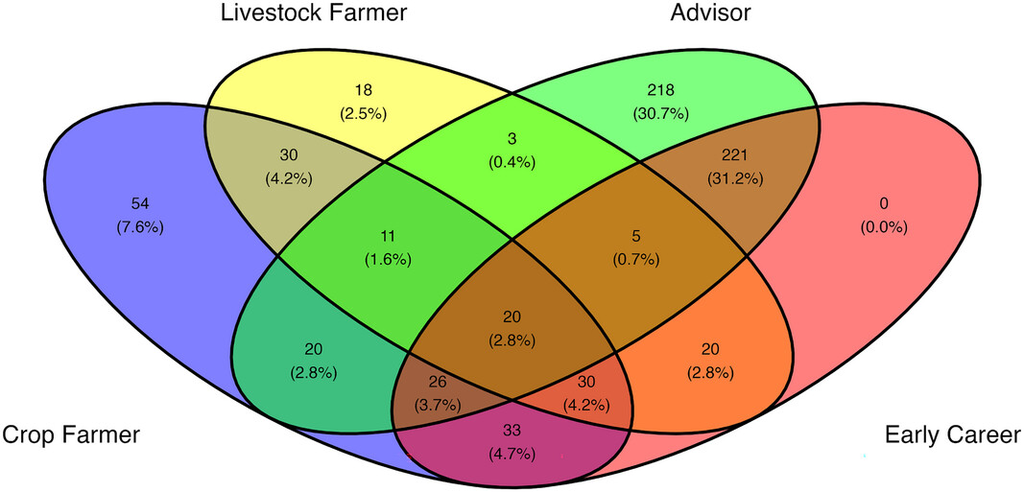

**FIGURE 1**

Open in figure viewer

Venn diagram illustrating relative frequencies of membership in overlapping demographic categories (*n* = 709).

We examined effects of demographics on ratings of benefits and knowledge using proportional odds cumulative logistic models (Bürkner & Vuorre, 2019) estimated with the “ordinal” package (Christensen, 2024). The proportional odds cumulative logistic model assumes that a continuous dependent variable underlies the responses observed on an ordinal scale. As the name implies, the effects of independent variables are fixed to equality across rating categories. We allowed flexible thresholds between response categories. For simplicity, we expressed results as prevalence ratios (Supporting Information Appendix 2). The prevalence ratio expresses the probability of exceeding a scale cutpoint (selecting “Slightly Beneficial” or “Beneficial”; selecting “Very Knowledgeable”) when a binary independent variable equals one relative to the exceedance probability when the independent variable is set to 0, holding other independent variables at their mean values. We modeled binary responses to barriers and resources using log-link binomial generalized linear models estimated with the “logbin” package (Donoghoe et al., 2021). We expressed results as prevalence ratios indicating the relative probability of selecting an item as a barrier when a binary independent variable equaled 1 versus 0, when other independent variables were held at their mean. We computed exceedance probabilities for all models using the “emmeans” package. For cumulative logistic and log-binomial models, we verified model assumptions were met by graphically inspecting surrogate residuals and deviance residuals, respectively (Greenwell et al., 2018; Liu & Zhang, 2018).

## 3 RESULTS

We conducted an exploratory descriptive survey of farmers and advisors in the United States and Canada to characterize their ratings of manure use benefits, self-reported knowledge of manure impacts on cropping systems, judgments of barriers to manure use, and useful information resources. To inform targeted extension and outreach programming, we explored associations between response choices and participants’ roles and years of experience. Importantly, our results were influenced by methodological choices and should be interpreted in light of the survey design and participant characteristics. First, our research team developed a quantitative survey based on commonly reported benefits and barriers to manure use, which constrained the scope of potential benefits and barriers addressed. Additionally, our study used a snowball sampling method to maximize responses (Parker et al., 2019). This nonrandom sampling method may have biased participation toward highly interested and knowledgeable respondents, who may also be likely to participate in extension and outreach events. Therefore, our findings specifically address topics and participant characteristics commonly encountered in manure use education and extension.

### 3.1 Demographics

Table 1 shows the count and relative frequencies for participant self-reported demographic categories. Most participants described themselves as from the Corn Belt and the High Plains regions of the United States (67%), with other regions of the United States and Canada selected by 20% and 13% of respondents, respectively. Therefore, our participants primarily represented intensive agricultural regions where corn, soybeans, and wheat were likely the majority of manured crop acres (Lim et al., 2023). We did not query the types and sources of manure that respondents encountered. However, the predominance of beef, dairy, and swine farms in these regions suggests that our participants may have had experience with a variety of solid and liquid manure types (Pagliari et al., 2020; H. Zhang & Schroder, 2014). Finally, our respondents predominantly described themselves as male (87%). However, people self-identifying as “Female” formed a substantially larger fraction of early-career respondents (26.5%) compared with their prevalence in later career respondents (5.5%). This illustrates a small but growing involvement of women in manure use decisions in the United States and Canada, aligning with the results of Cortus et al. (2018). The survey instrument had no option for other gender identities, so it is likely that participants who identified as neither male nor female chose not to respond to this item. Future work should explore gender in greater detail.

TABLE 1. Demographic count and relative frequencies.

| Category | *n* | % |
| --- | --- | --- |
| **Region** |  |  |
| US Corn Belt | 245 | 44.5 |
| US High Plains | 127 | 23.1 |
| Northeast United States | 44 | 8 |
| Western United States | 43 | 7.8 |
| Western Canada | 36 | 6.5 |
| Eastern Canada | 33 | 6 |
| Southeast United States | 22 | 4 |
| Total | 550 | 100 |
| **Gender** |  |  |
| Male | 604 | 86.9 |
| Female | 91 | 13.1 |
| Total | 695 | 100 |
| **Advisory role** |  |  |
| Retail agronomy products and technical services to farmers through a co-op or other private business. | 181 | 34.5 |
| Independent technical services to farmers or animal feeding operations (including private sector technical service providers). | 138 | 26.3 |
| Technical advice and education as an extension professional | 74 | 14.1 |
| Regulatory compliance services and/or professional guidance as an employee of a public regulatory or agricultural agency. | 56 | 10.7 |
| Technical services through a natural resource or conservation agency (e.g., Natural Resources Conservation Service, Forest Service, Natural Resource or Soil Conservation District, etc.) | 46 | 8.8 |
| Technical advice and education as a university professional | 17 | 3.2 |
| Manure sale, hauling and/or land application services | 12 | 2.3 |
| Total | 524 | 100 |
| **Years career experience** |  |  |
| More than 30 years | 200 | 28.2 |
| 21–30 years | 154 | 21.7 |
| 11–20 years | 154 | 21.7 |
| 6–10 years | 116 | 16.4 |
| Less than 5 years | 85 | 12 |
| Total | 709 | 100 |

TABLE 2. Count and relative frequency describing the frequency of manure use (crop farmers and livestock farmers) and frequency of advising about manure management (public and private sector advisors).<sup>a</sup>

| Category | *n* | % |
| --- | --- | --- |
| **Frequency of using manure in crop fertility programs** |  |  |
| Annually use animal manure (every year) | 138 | 75 |
| Never use animal manure | 17 | 9.2 |
| Frequently use animal manure (within the last 3 years) | 16 | 8.7 |
| Occasionally use animal manure (within the past 4–6 years) | 13 | 7.1 |
| Total | 184 | 100 |
| **Frequency of advising on manure as a part of crop fertility advising services** |  |  |
| Frequently advise on animal manure | 208 | 39.8 |
| Occasionally advise on animal manure | 195 | 37.3 |
| Animal manure is the primary focus of my advising services | 102 | 19.5 |
| Never advise on animal manure | 18 | 3.4 |
| Total | 523 | 100 |

- <sup>a</sup> Manure use frequency was queried for crop farmers and livestock farmers, excluding those with advising roles. Manure advising frequency was considered for any respondent with an advising role.

Table 3 illustrates how participants judged the complementarity or competitiveness between manure and fertilizer use. The majority of respondents (72%) indicated that manure and inorganic fertilizer had complementary roles in crop fertility programs. A small fraction (17%) of respondents reported that inorganic fertilizer and manure had competing roles, and most of this subset preferred inorganic fertilizer over manure. Indeed, two previous large meta-analyses of manure versus fertilizer comparisons observed that the highest yields occurred when both manure and fertilizer were used (Lin et al., 2018; Xia et al., 2017). Our study did not address specific situations in which manure or inorganic fertilizer was perceived as more appropriate or consider novel methods to combine manure with inorganic fertilizer. For example, recent studies demonstrated that co-application of manure with inorganic fertilizer may have synergistic effects on soil organic matter accumulation (Abdalla et al., 2022). Additionally, new technologies have expanded options for combining manure with inorganic compounds to create organomineral fertilizers with desirable nutrient composition (Smith et al., 2020). With additional research and development, it is plausible that manure and inorganic fertilizer may be viewed as increasingly complementary in future years.

TABLE 3. Count and relative frequencies of judging nutrient sources to be complementary or competitive.

| Category | *n* | % |
| --- | --- | --- |
| Fertilizer and manure regularly complement each other in crop fertility programs. | 510 | 72.0 |
| Fertilizer and manure are typically used independently and rarely are in competitive or complementary roles. | 79 | 11.2 |
| Fertilizer and manure are regularly competing against each other in crop fertility programs with fertilizer typically being the preferred option. | 69 | 9.7 |
| Fertilizer and manure are regularly competing against each other in crop fertility programs with manure typically being the preferred option. | 50 | 7.1 |
| Total | 708 | 100 |

### 3.2 Benefits of manure use and knowledge of manure impacts

Figure 2A presents participant ratings of manure impacts on cropping systems. Advisors and farmers shared that manure was beneficial for crop nutrition and fertility, yields, and soil characteristics. Among all respondents, Beneficial or Slightly Beneficial ratings were at least 90% of the responses given to crop nutrition and fertility (92% and 7%, respectively), soil biological characteristics (80% and 16%, respectively), soil physical characteristics (73% and 17%, respectively), and changes in crop yields (69% and 23%, respectively). Studies have shown that farmer adoption of practices is primarily motivated by desires to increase productivity and profitability (Ranjan et al., 2019; Rhymes et al., 2021; Rust et al., 2021), suggesting that manure benefits in these areas may strongly influence farmer and advisor behavior. Our findings illustrate strong recognition of the value of manure to crop yields and soil health, suggesting that further efforts to build awareness of these benefits may offer modest value. Participants also reported high knowledge of manure impacts on these cropping system characteristics, with “Moderately” to “Very” knowledgeable selected most frequently (Figure 3A). Our results suggested generally high knowledge of manure use in cropping systems, in agreement with Cortus et al. (2018). This contrasts the results of Herrero et al. (2018) where low knowledge was a limiting factor in manure use. Importantly, many of our participants reported using or advising on manure regularly (Table 2), indicating substantial on-the-job experience with manure use. In summary, our respondents generally perceived manure as valuable to cropping systems in terms of crop yields and soil characteristics and reported high knowledge of manure impacts on these areas.

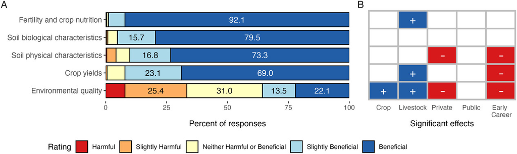

**FIGURE 2**

Open in figure viewer

(A) Relative percentage of responses in each category and (B) directionality of significant effects (*p* < 0.05) of binary demographic categories on the probability of selecting “Slightly Beneficial” or “Beneficial.” Self-report data from *n* = 709 respondents. Crop, crop farmer; Early Career, 20 or fewer years of experience; Livestock, livestock farmer; Private, private sector advisor; Public, public sector advisor.

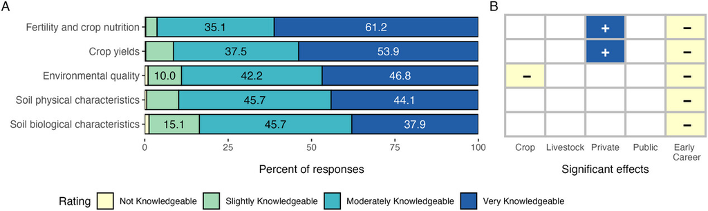

**FIGURE 3**

Open in figure viewer

(A) Relative percentage of responses in each category and (B) directionality of significant effects (*p* < 0.05) of binary demographic categories on the probability of selecting “Very Knowledgeable.” Self-report data from *n* = 709 respondents. Crop, crop farmer; Early Career = 20 or fewer years of experience; Livestock, livestock farmer; Private, private sector advisor; Public, public sector advisor.

Although respondents generally rated manure as beneficial, we found mixed perceptions regarding the impacts of manure use on environmental quality: manure was described as Harmful, Neutral, and Beneficial at approximately equal frequencies (33.4%, 31.0%, and 35.6%, respectively; Figure 2A). Our respondents considered themselves knowledgeable about manure impacts on environmental quality (Figure 3A), implying that they provided an informed assessment of manure benefits and harms based on their experience. Indeed, some studies showed manure misapplication and poor adherence to nutrient management plans in certain US regions (Long et al., 2018; Osmond et al., 2015), so that farmers and advisors may associate manure with harmful environmental effects. Manure use has an extended history of regulations to protect environmental quality, which may lead to perceptions of manure as generally harmful or dangerous to the environment. More generally, manure is often framed as a waste rather than a resource (Åkerman et al., 2020; Gesing, 2023). It is unclear how stakeholders conceptualize manure's potential for environmental benefits and harms, that is, what environmental sustainability framings shape their valuation of manure. This suggests that education and extension professionals have opportunities to improve the perceived value of manure by illustrating connections between manure use and environmental quality and by reframing manure use within the context of nutrient circularity.

In several cases, ratings of manure benefits and knowledge were associated with demographic characteristics (Figures 2B and 3B). First, compared with others in the sample, livestock farmers rated manure as more beneficial to crop nutrition and yields. Our findings agree with the northeastern Colorado survey of Stroheim and Hoag (2021), which found that farmers who used manure from their own livestock assigned a higher economic value to manure than those who did not use manure or who purchased manure. Second, in our study, farming roles were also associated with describing manure as more beneficial to environmental quality, though crop farmers claimed lower knowledge in this area. Third, private sector advisors rated manure as less beneficial to soil physical characteristics and environmental quality compared with others in the sample. Private sector advisors also had higher self-assessed knowledge of manure impacts on crop nutrition and yields, consistent with their orientation toward farm profit maximization (Beethem et al., 2023; Pedersen et al., 2019). Finally, in our study, early-career respondents generally had less-favorable ratings of manure benefits and lower self-assessments of knowledge about manure impacts. This contrasted recent research showing that younger farmers had greater interest in using manure as a fertilizer (Case et al., 2017). Moreover, it may suggest that knowledge of manure use stems primarily from on-the-job experience and informal education rather than formal education.

Several methodological considerations emerged from our study of manure benefits and knowledge. We asked participants whether manure use was generally beneficial to certain aspects of cropping systems. Future studies could also investigate the perceived benefits of manure use compared with realistic alternatives, such as using commercial inorganic fertilizer. Such research could employ quantitative (e.g., multi-attribute ranking and choice experiments) or qualitative approaches. Additionally, our assessments of perceived benefits and knowledge may have been biased by social desirability of these outcomes among participants (Vesely & Klöckner, 2020). Future studies could consider indirect questioning, implicit associations, and objective knowledge assessments when studying stakeholders’ manure use perceptions (Kwak et al., 2021).

### 3.3 Barriers to manure use

Figure 4A depicts the relative frequencies with which participants selected items as barriers to manure use. Of the list of potential barriers, three items emerged as common barriers. Considering that our survey included multiple production systems, roles, and regions, the high percentage of respondents selecting these items illustrates that these barriers limit manure use in a variety of United States and Canadian contexts. First, nearly all participants (91%) indicated that the cost of manure transportation and land application limited its use. Manure typically has higher water and/or soil content than other fertilizer sources, which can increase transportation and application costs (Åkerman et al., 2020). In the long term, this barrier may be addressed by implementing technologies to concentrate manure nutrients (Ahmed et al., 2019). However, there is potential for immediate impact by enabling producers to compare manure transportation costs in relation to profitability for specific fields. The second most frequently selected barrier was odors and air quality impairment (79% of participants). Various tools have been developed to assist farmers and advisors in planning for and reducing odor risks (Akter, 2018). However, our results suggest that existing tools and technologies have not eliminated odor and air quality concerns.

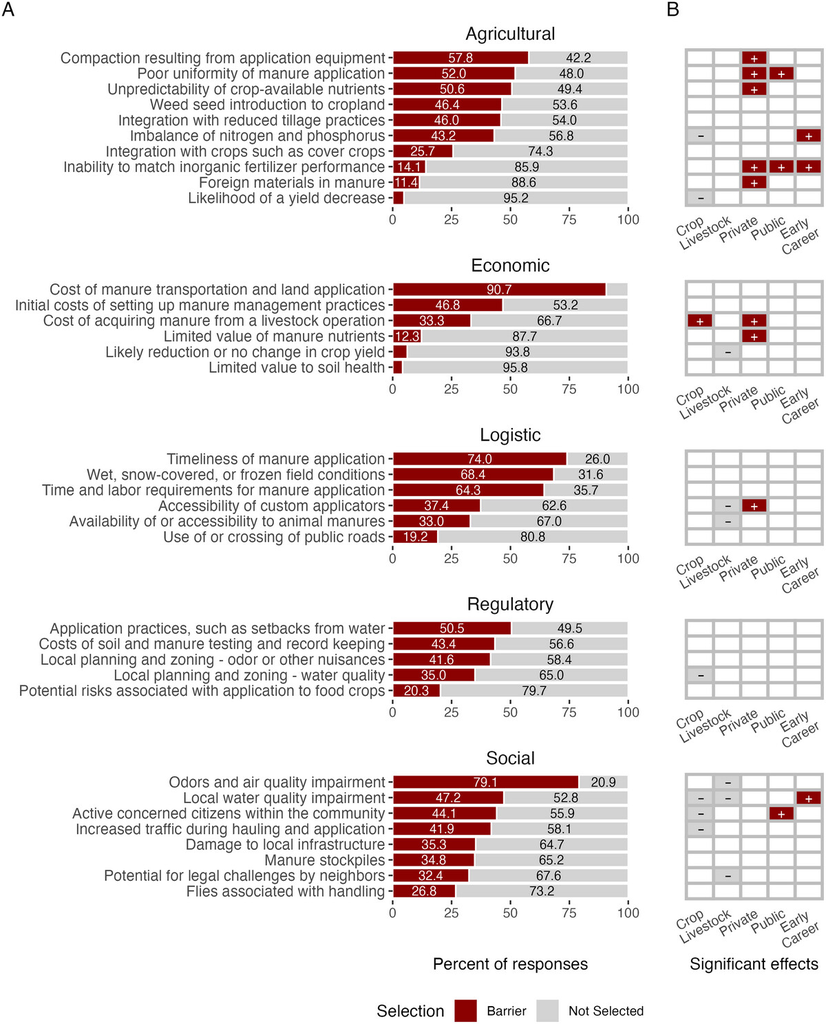

**FIGURE 4**

Open in figure viewer

(A) Relative percentage of responses in each category and (B) directionality of significant effects (*p* < 0.05) of binary demographic categories on the probability of selecting an item as a barrier. Self-report data from *n* = 709 respondents. Crop, crop farmer; Early Career, 20 or fewer years of experience; Livestock, livestock farmer; Private, private sector advisor; Public, public sector advisor; Models did not converge for “Cost of manure transportation and land application” and “Limited value to soil health,” so no effects could be reported in panel (B).

The third most-selected barrier to manure use (74% of participants) was the timeliness of manure application, and logistical challenges presented three of the top five most-selected barriers in our study. Indeed, recent studies showed that farmer decisions to apply manure were primarily driven by practical constraints such as time, cost, and labor (Micha et al., 2020). Continued efforts to overcome the universal barriers of transportation and application costs, odors and air quality, and timeliness of manure application may have drastic implications for expanding manure use. To illustrate, Núñez and McCann (2004) found that farmers who viewed manure transportation costs and odors as problematic were about 20% less likely to use manure.

To overcome these challenges, recent authors suggested a need for “manureshed management” through public and private mechanisms facilitating manure exchange and use (Flynn et al., 2023; Sharara et al., 2022). For example, manure brokering, transportation, and land application services have potential to alleviate labor and equipment limitations to manure use (McCann et al., 2005), and information systems such as the Nutrient Use Geography Information System (The Fertilizer Institute, 2025) may promote collaborative effort. Additionally, there is a need for extension on practices that create alternative time windows for manure application such as side dressing onto established crops (Pfarr et al., 2020).

Manure use poses a variety of agronomic concerns such as soil compaction, poor uniformity in chemical composition, and potential for weed seed contamination and herbicide resistance. In our study, these challenges were selected as barriers to a moderate degree. This could suggest that these barriers are specific to certain regions, cropping systems, or farmer subgroups (e.g., smallholders; Grover & Gruver, 2017) rather than representing universal concerns. As such, there remains a need for education and extension on precision manure application, designer manures (Meyer & Robinson, 2007), and manure treatment tailored to local needs. Education and technical services may need to transition to focus on specific issues, such as assisting farmers and advisors with (1) determining how to meet crop nutrient needs with manure, (2) estimating the fertilizer replacement value of manure and understanding what nutrients contribute the most significant value, and (3) identifying where and when complementary use of manure and fertilizer may help optimize crop yields. In our study, very few participants reported that the likelihood of a yield decrease (5%) or limited value to soil health (4%) represented barriers to manure use, although our research team identified these items as potential barriers. Taken together with ratings of manure benefits, these results reinforce that manure was widely viewed as a positive contributor to improved crop yields and suggest that respondents accurately associate overall soil health with soil physical and biological properties.

Respondents with different roles and years of experience differed in their reports of manure barriers (Figure 4B). Compared with others in the sample, crop and livestock farmers were less likely to select manure barriers in several instances. Crop farmers indicated lower concern regarding imbalanced N and P, yield losses, local planning and zoning, water quality impairment, concerned community members, and increased traffic. Livestock farmers were less likely to select yield losses, accessibility of custom applicators, manure availability, odors, water quality impairment, and legal challenges as barriers to manure use. However, crop farmers were more likely to select the cost of acquiring manure as a barrier to its use, suggesting that extension programming on quantifying the value of manure based on their specific fertility needs may appeal to them. In general, our findings show that crop and livestock farmers reported fewer barriers to manure use compared with other respondents, especially reporting fewer social barriers. This may indicate that farmers have developed ways to effectively use manure within their local social and environmental contexts or that they lack awareness of negative externalities of manure use. Future research could triangulate perspectives of multiple stakeholders (farmers, advisors, and local community members) to determine which is true.

In comparison with all other respondents, responses from private sector, and to a lesser extent, public sector advisors suggested greater awareness of potential agricultural challenges associated with manure use in cropping systems. Interestingly, we observed a relationship between private but not public sector advising with selecting the “cost of acquiring manure” and “limited value of manure nutrients” as barriers to manure use. Taken together, these responses suggest that advisors differed from other respondents in their valuation of the costs and benefits of manure use. Advisors likely have experience with a wider variety of manure use circumstances compared with farmer respondents. Because advisors are not obligatory manure users, they may also have experience with a wider variety of fertilizer sources. It is possible that advisors account for manure use costs differently than farmers, for example, by factoring in greater costs for laboratory analysis when using manure versus other fertilizers (T. Zhang et al., 2021). Interestingly, public but not private sector advisors were more likely than other respondents to indicate active concerned citizens within the community as a barrier to manure use. Public sector advisors have regular encounters with a wide cross-section of stakeholders (Prokopy et al., 2015), which may make them more attuned to community concerns. Overall, our findings suggest that advisors may favor extension programming that enhances their ability to troubleshoot a variety of manure use barriers and to compare manure's value against alternative nutrient sources.

Finally, early-career respondents (20 or fewer years of experience) were more likely to report that balancing N and P, matching inorganic fertilizer performance, and protecting local water quality represented barriers to manure use. Battel and Krueger (2005) similarly showed that younger farmers (<50 years of age) were more concerned with manure use barriers than older counterparts. The distinct responses of early career participants could signify broader changes in the agricultural system that are emerging concerns. However, in our study, early-career respondents also had lower ratings of manure benefits and lower self-assessments of knowledge about manure impacts on cropping systems. Considered together, these results could indicate that early-career respondents saw themselves as generally less knowledgeable about manure use and less competent at overcoming certain manure barriers. Therefore, our results suggest that early-career professionals are an important target for extension and education work to (1) enhance awareness of manure benefits, (2) improve knowledge of manure impacts on cropping systems, and (3) improve their competence in overcoming barriers to manure use. However, future work should explore the degree to which perceived barriers of manure use represent low self-efficacy versus external conditions.

### 3.4 Useful decision-making and education resources

Figure 5A shows the relative frequencies with which participants selected items as information resources they are likely to use. Most respondents reported that they would use fact sheets or news articles and their professional network as information sources. Approximately half of participants claimed that they were likely to use recommended research articles. This aligns with recent research showing that farmers rely on multiple information sources when making nutrient management decisions (Houser et al., 2019; O'Connell & Osmond, 2022), and that US farmers and advisors have strong trust in university research and extension (Borrelli et al., 2018; Pires et al., 2024; Prokopy et al., 2015). In our study, participants infrequently selected decision support tools, short videos or podcasts, and social media resources as useful information resources. This agrees with Cortus et al. (2018), which similarly found that decision support tools, podcasts, and social media had low relevance as information sources to United States and Canadian manure nutrient management professionals, compared with high relevance of learning in field or farm settings. By contrast, studies in New Zealand and Europe demonstrated that social media served as an important mechanism for social learning among farmers and advisors (Phillips et al., 2021; Rust et al., 2021). These contrasting findings may indicate regional differences or a discrepancy between perceived versus actual influence of social media on decision-making. In summary, our findings support the contention that farming decisions stem from pluralistic knowledge and innovation networks, where information transfers through various means including self-education, peer-to-peer interactions, and expert-driven learning (Klerkx, 2020; Rust et al., 2021), though scientific information sources and professional networks were selected most frequently by our participants. Whereas our study considered *whether or not* participants were likely to use certain resources, future research could further elucidate information use intensity by exploring *how often* and *under what circumstances* specific sources are used (Beethem et al., 2023).

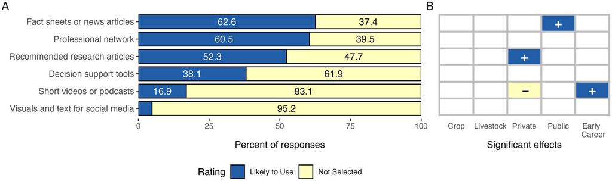

**FIGURE 5**

Open in figure viewer

(A) Relative percentage of responses in each category and (B) directionality of significant effects (*p* < 0.05) of binary demographic categories on the probability of selecting a resource as “likely to use.” Self-report data from *n* = 709 respondents. Crop, crop farmer; Early Career, 20 or fewer years of experience; Livestock, livestock farmer; Private, private sector advisor; Public, public sector advisor.

Figure 5B shows the direction of significant relationships between demographic categories and useful information resources. Interestingly, private and public sector advisors indicated themselves as more likely to use recommended research articles and fact sheets, respectively, to source information on manure. This exemplifies that advisors seek scientific information to a greater extent than others surveyed, in alignment with the finding of Cortus et al. (2018) and studies showing that advisors are critical intermediaries in disseminating scientific information across agricultural knowledge networks (Klerkx, 2020; Prokopy et al., 2015). To determine the direction of future information needs, we studied differences between respondents in early (≤20 years) or late career stages. We found that early-career respondents were substantially more likely to indicate videos and podcasts as a useful information source than later career respondents. This may be an early indication of shifting preferences toward multimedia information resources. Our study did not delineate whether the responses of early career respondents differed due to years of professional experience per se or due to age. When considering years of professional experience, Houser et al. (2019) observed that less-experienced farmers drew on more information sources when making nutrient management decisions, possibly due to greater openness or information literacy (O'Connell & Osmond, 2022). Research has also suggested age-related differences in sourcing agricultural information. Witzling et al. (2023) found that participants who attended virtual extension programming were younger than those who attended solely in-person events, and that these participants reported greater use of social media and podcasts to source agricultural information. In summary, our findings imply that advisors demand scientific information to a greater extent than other participants, and that early-career professionals may be receptive users and conduits of various forms of information.

## 4 CONCLUSIONS

We surveyed 709 people representing crop farmers, animal feeding operation managers, and advisors providing technical and educational services connected with land application of animal manures in the United States and Canada. Notably, respondents to this survey heavily represented the Corn Belt and High Plains region of the United States and private sector advisors. We found that manure was largely viewed as complementary to inorganic fertilizer, and that respondents strongly recognized manure benefits to crop yield, soil fertility, and soil health. By contrast, respondents shared mixed perceptions regarding the impacts of manure on environmental quality, suggesting a need for further research on perceptions of specific environmental risks and benefits associated with manure use. The most-selected barriers to manure use were (1) the cost of manure transportation and land application, (2) odors and air quality impairment, and (3) the timeliness of manure application, indicating these concerns affect most stakeholders across the United States and Canada. Our respondents described themselves as highly knowledgeable about manure impacts on cropping systems and reported using primarily scientific information sources and their professional networks in making manure nutrient management decisions. Additionally, we showed that respondents’ roles in farming and advising and their years of professional experience were associated with distinct patterns of responses, illustrating opportunities to tailor extension and outreach programming. Respondents in crop or livestock farmer roles generally rated manure as more beneficial to cropping systems and selected various barriers to manure use less often than other respondents. This suggested that farmers generally viewed manure as beneficial but may require extension and education to overcome specific challenges in manure use. At the same time, we observed that advisors rated themselves as more knowledgeable about manure impacts, but were more likely to select certain agricultural, economic, and logistic challenges as barriers to manure use. This showed that advisors may benefit from extension programming that enhances their ability to troubleshoot a wide variety of manure use barriers. Finally, early-career respondents rated themselves as less knowledgeable and were more likely to select various barriers to manure use. Therefore, early career professionals may be an important target for extension and education work to (1) enhance awareness of manure benefits, (2) improve knowledge of manure impacts on cropping systems, and (3) improve their competence in overcoming barriers to manure use. In summary, our results suggested broad recognition of manure benefits to crop yields and soil properties and emphasized a need to develop scientific information resources and professional development opportunities enabling stakeholders to overcome barriers to manure use in cropping systems.

## AUTHOR CONTRIBUTIONS

**MaryGrace Erickson**: Formal analysis; investigation; methodology; visualization; writing—original draft; writing—review and editing. **Erin Cortus**: Conceptualization; investigation; methodology; resources; supervision; validation; visualization; writing—review and editing. **Rick Koelsch**: Conceptualization; data curation; formal analysis; funding acquisition; investigation; methodology; project administration; resources; software; supervision; validation; writing—review and editing. **Leslie Johnson**: Conceptualization; data curation; methodology; resources; visualization. **Melissa Wilson**: Conceptualization; funding acquisition; investigation; methodology; resources; validation; writing—original draft; writing—review and editing. **Dan Andersen**: Conceptualization; funding acquisition; investigation; methodology; resources. **Mara Zelt**: Data curation; formal analysis; investigation; visualization; writing—review and editing. **Amy Schmidt**: Conceptualization; data curation; formal analysis; funding acquisition; investigation; methodology; project administration; resources; software; supervision; validation; visualization; writing—original draft; writing—review and editing.

## ACKNOWLEDGMENTS

Key partners in survey deployment were the American Agronomy Society Certified Crop Advisor Program, the Fertilizer Institute, and *Manure Manager* magazine. This work was funded by North Central SARE project ENC18-173.

## CONFLICT OF INTEREST STATEMENT

The authors declare no conflicts of interest.

## REFERENCES

[figure not shown]

[Volume117, Issue4](https://acsess.onlinelibrary.wiley.com/toc/14350645/2025/117/4)

July/August 2025

e70110

### Recommended

  [Agronomy Journal](https://acsess.onlinelibrary.wiley.com/journal/14350645)

[Download PDF](https://acsess.onlinelibrary.wiley.com/doi/pdf/10.1002/agj2.70110)

back